# processo seletivo

Clevia

2022-11-12

# entrada dos dados

```r
library(readxl)
diesel <- read_excel("/Users/Clevia/Documents/4inteligence/dados_desafiodatascientistintern_vendas_distribuidoras_anp.xlsx", sheet = 1)

gasolina <- read_excel("/Users/Clevia/Documents/4inteligence/dados_desafiodatascientistintern_vendas_distribuidoras_anp.xlsx", sheet = 2)

etanol <- read_excel("/Users/Clevia/Documents/4inteligence/dados_desafiodatascientistintern_vendas_distribuidoras_anp.xlsx", sheet = 3)
```

# Diesel

```r
require(dplyr)
require(tidyverse)

df0 <- diesel%>% filter(regiao=="df")

df00 <- df0[,c(1,2,3)] %>% rename(m3diesel = "2000" )
df1 <- df0[,c(1,2,4)]  %>% rename(m3diesel = "2001" )
df2 <- df0[,c(1,2,5)]  %>% rename(m3diesel = "2002" )
df3 <- df0[,c(1,2,6)]  %>% rename(m3diesel = "2003" )
df4 <- df0[,c(1,2,7)]  %>% rename(m3diesel = "2004" )
df5 <- df0[,c(1,2,8)]  %>% rename(m3diesel = "2005" )
df6 <- df0[,c(1,2,9)]  %>% rename(m3diesel = "2006" )
df7 <- df0[,c(1,2,10)]  %>% rename(m3diesel = "2007" )
df8 <- df0[,c(1,2,11)]  %>% rename(m3diesel = "2008" )
df9 <- df0[,c(1,2,12)]  %>% rename(m3diesel = "2009" )
df10 <- df0[,c(1,2,13)]  %>% rename(m3diesel = "2010" )
df11 <- df0[,c(1,2,14)]  %>% rename(m3diesel = "2011" )
df12 <- df0[,c(1,2,15)]  %>% rename(m3diesel = "2012" )
df13 <- df0[,c(1,2,16)]  %>% rename(m3diesel = "2013" )
df14 <- df0[,c(1,2,17)]  %>% rename(m3diesel = "2014" )
df15 <- df0[,c(1,2,18)]  %>% rename(m3diesel = "2015" )
df16 <- df0[,c(1,2,19)]  %>% rename(m3diesel = "2016" )
df17 <- df0[,c(1,2,20)]  %>% rename(m3diesel = "2017" )
df18 <- df0[,c(1,2,21)]  %>% rename(m3diesel = "2018" )
df19 <- df0[,c(1,2,22)]  %>% rename(m3diesel = "2019" )
df20 <- df0[,c(1,2,23)]  %>% rename(m3diesel = "2020" )

df_total <- bind_rows(df00,df1,df2,df3,df4,df5,df6,df7,df8,df9,df10,df11,df12,df13,df14,df15,df16,df17,df18,df19,df20)
```

```r
require(lubridate)
ano <- seq.Date(from = as_date("2000-01-01"),
         to = as_date("2020-12-01"),
         by = "1 month")

df_total<- cbind(df_total,ano)
```

```r
df0 <- diesel%>% filter(regiao=="go")

df00 <- df0[,c(1,2,3)] %>% rename(m3diesel = "2000" )
df1 <- df0[,c(1,2,4)]  %>% rename(m3diesel = "2001" )
df2 <- df0[,c(1,2,5)]  %>% rename(m3diesel = "2002" )
df3 <- df0[,c(1,2,6)]  %>% rename(m3diesel = "2003" )
df4 <- df0[,c(1,2,7)]  %>% rename(m3diesel = "2004" )
df5 <- df0[,c(1,2,8)]  %>% rename(m3diesel = "2005" )
df6 <- df0[,c(1,2,9)]  %>% rename(m3diesel = "2006" )
df7 <- df0[,c(1,2,10)]  %>% rename(m3diesel = "2007" )
df8 <- df0[,c(1,2,11)]  %>% rename(m3diesel = "2008" )
df9 <- df0[,c(1,2,12)]  %>% rename(m3diesel = "2009" )
df10 <- df0[,c(1,2,13)]  %>% rename(m3diesel = "2010" )
df11 <- df0[,c(1,2,14)]  %>% rename(m3diesel = "2011" )
df12 <- df0[,c(1,2,15)]  %>% rename(m3diesel = "2012" )
df13 <- df0[,c(1,2,16)]  %>% rename(m3diesel = "2013" )
df14 <- df0[,c(1,2,17)]  %>% rename(m3diesel = "2014" )
df15 <- df0[,c(1,2,18)]  %>% rename(m3diesel = "2015" )
df16 <- df0[,c(1,2,19)]  %>% rename(m3diesel = "2016" )
df17 <- df0[,c(1,2,20)]  %>% rename(m3diesel = "2017" )
df18 <- df0[,c(1,2,21)]  %>% rename(m3diesel = "2018" )
df19 <- df0[,c(1,2,22)]  %>% rename(m3diesel = "2019" )
df20 <- df0[,c(1,2,23)]  %>% rename(m3diesel = "2020" )

go_total <- bind_rows(df00,df1,df2,df3,df4,df5,df6,df7,df8,df9,df10,df11,df12,df13,df14,df15,df16,df17,df18,df19,df20)
go_total<- cbind(go_total,ano)
```

```r
df0 <- diesel%>% filter(regiao=="ma")

df00 <- df0[,c(1,2,3)] %>% rename(m3diesel = "2000" )
df1 <- df0[,c(1,2,4)]  %>% rename(m3diesel = "2001" )
df2 <- df0[,c(1,2,5)]  %>% rename(m3diesel = "2002" )
df3 <- df0[,c(1,2,6)]  %>% rename(m3diesel = "2003" )
df4 <- df0[,c(1,2,7)]  %>% rename(m3diesel = "2004" )
df5 <- df0[,c(1,2,8)]  %>% rename(m3diesel = "2005" )
df6 <- df0[,c(1,2,9)]  %>% rename(m3diesel = "2006" )
df7 <- df0[,c(1,2,10)]  %>% rename(m3diesel = "2007" )
df8 <- df0[,c(1,2,11)]  %>% rename(m3diesel = "2008" )
df9 <- df0[,c(1,2,12)]  %>% rename(m3diesel = "2009" )
df10 <- df0[,c(1,2,13)]  %>% rename(m3diesel = "2010" )
df11 <- df0[,c(1,2,14)]  %>% rename(m3diesel = "2011" )
df12 <- df0[,c(1,2,15)]  %>% rename(m3diesel = "2012" )
df13 <- df0[,c(1,2,16)]  %>% rename(m3diesel = "2013" )
df14 <- df0[,c(1,2,17)]  %>% rename(m3diesel = "2014" )
df15 <- df0[,c(1,2,18)]  %>% rename(m3diesel = "2015" )
df16 <- df0[,c(1,2,19)]  %>% rename(m3diesel = "2016" )
df17 <- df0[,c(1,2,20)]  %>% rename(m3diesel = "2017" )
df18 <- df0[,c(1,2,21)]  %>% rename(m3diesel = "2018" )
df19 <- df0[,c(1,2,22)]  %>% rename(m3diesel = "2019" )
df20 <- df0[,c(1,2,23)]  %>% rename(m3diesel = "2020" )

ma_total <- bind_rows(df00,df1,df2,df3,df4,df5,df6,df7,df8,df9,df10,df11,df12,df13,df14,df15,df16,df17,df18,df19,df20)
ma_total<- cbind(ma_total,ano)
```

```r
df0 <- diesel%>% filter(regiao=="mt")

df00 <- df0[,c(1,2,3)] %>% rename(m3diesel = "2000" )
df1 <- df0[,c(1,2,4)]  %>% rename(m3diesel = "2001" )
df2 <- df0[,c(1,2,5)]  %>% rename(m3diesel = "2002" )
df3 <- df0[,c(1,2,6)]  %>% rename(m3diesel = "2003" )
df4 <- df0[,c(1,2,7)]  %>% rename(m3diesel = "2004" )
df5 <- df0[,c(1,2,8)]  %>% rename(m3diesel = "2005" )
df6 <- df0[,c(1,2,9)]  %>% rename(m3diesel = "2006" )
df7 <- df0[,c(1,2,10)]  %>% rename(m3diesel = "2007" )
df8 <- df0[,c(1,2,11)]  %>% rename(m3diesel = "2008" )
df9 <- df0[,c(1,2,12)]  %>% rename(m3diesel = "2009" )
df10 <- df0[,c(1,2,13)]  %>% rename(m3diesel = "2010" )
df11 <- df0[,c(1,2,14)]  %>% rename(m3diesel = "2011" )
df12 <- df0[,c(1,2,15)]  %>% rename(m3diesel = "2012" )
df13 <- df0[,c(1,2,16)]  %>% rename(m3diesel = "2013" )
df14 <- df0[,c(1,2,17)]  %>% rename(m3diesel = "2014" )
df15 <- df0[,c(1,2,18)]  %>% rename(m3diesel = "2015" )
df16 <- df0[,c(1,2,19)]  %>% rename(m3diesel = "2016" )
df17 <- df0[,c(1,2,20)]  %>% rename(m3diesel = "2017" )
df18 <- df0[,c(1,2,21)]  %>% rename(m3diesel = "2018" )
df19 <- df0[,c(1,2,22)]  %>% rename(m3diesel = "2019" )
df20 <- df0[,c(1,2,23)]  %>% rename(m3diesel = "2020" )

mt_total <- bind_rows(df00,df1,df2,df3,df4,df5,df6,df7,df8,df9,df10,df11,df12,df13,df14,df15,df16,df17,df18,df19,df20)
mt_total<- cbind(mt_total,ano)
```

```r
df0 <- diesel%>% filter(regiao=="mg")

df00 <- df0[,c(1,2,3)] %>% rename(m3diesel = "2000" )
df1 <- df0[,c(1,2,4)]  %>% rename(m3diesel = "2001" )
df2 <- df0[,c(1,2,5)]  %>% rename(m3diesel = "2002" )
df3 <- df0[,c(1,2,6)]  %>% rename(m3diesel = "2003" )
df4 <- df0[,c(1,2,7)]  %>% rename(m3diesel = "2004" )
df5 <- df0[,c(1,2,8)]  %>% rename(m3diesel = "2005" )
df6 <- df0[,c(1,2,9)]  %>% rename(m3diesel = "2006" )
df7 <- df0[,c(1,2,10)]  %>% rename(m3diesel = "2007" )
df8 <- df0[,c(1,2,11)]  %>% rename(m3diesel = "2008" )
df9 <- df0[,c(1,2,12)]  %>% rename(m3diesel = "2009" )
df10 <- df0[,c(1,2,13)]  %>% rename(m3diesel = "2010" )
df11 <- df0[,c(1,2,14)]  %>% rename(m3diesel = "2011" )
df12 <- df0[,c(1,2,15)]  %>% rename(m3diesel = "2012" )
df13 <- df0[,c(1,2,16)]  %>% rename(m3diesel = "2013" )
df14 <- df0[,c(1,2,17)]  %>% rename(m3diesel = "2014" )
df15 <- df0[,c(1,2,18)]  %>% rename(m3diesel = "2015" )
df16 <- df0[,c(1,2,19)]  %>% rename(m3diesel = "2016" )
df17 <- df0[,c(1,2,20)]  %>% rename(m3diesel = "2017" )
df18 <- df0[,c(1,2,21)]  %>% rename(m3diesel = "2018" )
df19 <- df0[,c(1,2,22)]  %>% rename(m3diesel = "2019" )
df20 <- df0[,c(1,2,23)]  %>% rename(m3diesel = "2020" )

mg_total <- bind_rows(df00,df1,df2,df3,df4,df5,df6,df7,df8,df9,df10,df11,df12,df13,df14,df15,df16,df17,df18,df19,df20)
mg_total<- cbind(mg_total,ano)
```

```r
df0 <- diesel%>% filter(regiao=="pa")

df00 <- df0[,c(1,2,3)] %>% rename(m3diesel = "2000" )
df1 <- df0[,c(1,2,4)]  %>% rename(m3diesel = "2001" )
df2 <- df0[,c(1,2,5)]  %>% rename(m3diesel = "2002" )
df3 <- df0[,c(1,2,6)]  %>% rename(m3diesel = "2003" )
df4 <- df0[,c(1,2,7)]  %>% rename(m3diesel = "2004" )
df5 <- df0[,c(1,2,8)]  %>% rename(m3diesel = "2005" )
df6 <- df0[,c(1,2,9)]  %>% rename(m3diesel = "2006" )
df7 <- df0[,c(1,2,10)]  %>% rename(m3diesel = "2007" )
df8 <- df0[,c(1,2,11)]  %>% rename(m3diesel = "2008" )
df9 <- df0[,c(1,2,12)]  %>% rename(m3diesel = "2009" )
df10 <- df0[,c(1,2,13)]  %>% rename(m3diesel = "2010" )
df11 <- df0[,c(1,2,14)]  %>% rename(m3diesel = "2011" )
df12 <- df0[,c(1,2,15)]  %>% rename(m3diesel = "2012" )
df13 <- df0[,c(1,2,16)]  %>% rename(m3diesel = "2013" )
df14 <- df0[,c(1,2,17)]  %>% rename(m3diesel = "2014" )
df15 <- df0[,c(1,2,18)]  %>% rename(m3diesel = "2015" )
df16 <- df0[,c(1,2,19)]  %>% rename(m3diesel = "2016" )
df17 <- df0[,c(1,2,20)]  %>% rename(m3diesel = "2017" )
df18 <- df0[,c(1,2,21)]  %>% rename(m3diesel = "2018" )
df19 <- df0[,c(1,2,22)]  %>% rename(m3diesel = "2019" )
df20 <- df0[,c(1,2,23)]  %>% rename(m3diesel = "2020" )

pa_total <- bind_rows(df00,df1,df2,df3,df4,df5,df6,df7,df8,df9,df10,df11,df12,df13,df14,df15,df16,df17,df18,df19,df20)
pa_total<- cbind(pa_total,ano)
```

```r
df0 <- diesel%>% filter(regiao=="sp")

df00 <- df0[,c(1,2,3)] %>% rename(m3diesel = "2000" )
df1 <- df0[,c(1,2,4)]  %>% rename(m3diesel = "2001" )
df2 <- df0[,c(1,2,5)]  %>% rename(m3diesel = "2002" )
df3 <- df0[,c(1,2,6)]  %>% rename(m3diesel = "2003" )
df4 <- df0[,c(1,2,7)]  %>% rename(m3diesel = "2004" )
df5 <- df0[,c(1,2,8)]  %>% rename(m3diesel = "2005" )
df6 <- df0[,c(1,2,9)]  %>% rename(m3diesel = "2006" )
df7 <- df0[,c(1,2,10)]  %>% rename(m3diesel = "2007" )
df8 <- df0[,c(1,2,11)]  %>% rename(m3diesel = "2008" )
df9 <- df0[,c(1,2,12)]  %>% rename(m3diesel = "2009" )
df10 <- df0[,c(1,2,13)]  %>% rename(m3diesel = "2010" )
df11 <- df0[,c(1,2,14)]  %>% rename(m3diesel = "2011" )
df12 <- df0[,c(1,2,15)]  %>% rename(m3diesel = "2012" )
df13 <- df0[,c(1,2,16)]  %>% rename(m3diesel = "2013" )
df14 <- df0[,c(1,2,17)]  %>% rename(m3diesel = "2014" )
df15 <- df0[,c(1,2,18)]  %>% rename(m3diesel = "2015" )
df16 <- df0[,c(1,2,19)]  %>% rename(m3diesel = "2016" )
df17 <- df0[,c(1,2,20)]  %>% rename(m3diesel = "2017" )
df18 <- df0[,c(1,2,21)]  %>% rename(m3diesel = "2018" )
df19 <- df0[,c(1,2,22)]  %>% rename(m3diesel = "2019" )
df20 <- df0[,c(1,2,23)]  %>% rename(m3diesel = "2020" )

sp_total <- bind_rows(df00,df1,df2,df3,df4,df5,df6,df7,df8,df9,df10,df11,df12,df13,df14,df15,df16,df17,df18,df19,df20)
sp_total<- cbind(sp_total,ano)
```

```r
df0 <- diesel%>% filter(regiao=="to")

df00 <- df0[,c(1,2,3)] %>% rename(m3diesel = "2000" )
df1 <- df0[,c(1,2,4)]  %>% rename(m3diesel = "2001" )
df2 <- df0[,c(1,2,5)]  %>% rename(m3diesel = "2002" )
df3 <- df0[,c(1,2,6)]  %>% rename(m3diesel = "2003" )
df4 <- df0[,c(1,2,7)]  %>% rename(m3diesel = "2004" )
df5 <- df0[,c(1,2,8)]  %>% rename(m3diesel = "2005" )
df6 <- df0[,c(1,2,9)]  %>% rename(m3diesel = "2006" )
df7 <- df0[,c(1,2,10)]  %>% rename(m3diesel = "2007" )
df8 <- df0[,c(1,2,11)]  %>% rename(m3diesel = "2008" )
df9 <- df0[,c(1,2,12)]  %>% rename(m3diesel = "2009" )
df10 <- df0[,c(1,2,13)]  %>% rename(m3diesel = "2010" )
df11 <- df0[,c(1,2,14)]  %>% rename(m3diesel = "2011" )
df12 <- df0[,c(1,2,15)]  %>% rename(m3diesel = "2012" )
df13 <- df0[,c(1,2,16)]  %>% rename(m3diesel = "2013" )
df14 <- df0[,c(1,2,17)]  %>% rename(m3diesel = "2014" )
df15 <- df0[,c(1,2,18)]  %>% rename(m3diesel = "2015" )
df16 <- df0[,c(1,2,19)]  %>% rename(m3diesel = "2016" )
df17 <- df0[,c(1,2,20)]  %>% rename(m3diesel = "2017" )
df18 <- df0[,c(1,2,21)]  %>% rename(m3diesel = "2018" )
df19 <- df0[,c(1,2,22)]  %>% rename(m3diesel = "2019" )
df20 <- df0[,c(1,2,23)]  %>% rename(m3diesel = "2020" )

to_total <- bind_rows(df00,df1,df2,df3,df4,df5,df6,df7,df8,df9,df10,df11,df12,df13,df14,df15,df16,df17,df18,df19,df20)
to_total<- cbind(to_total,ano)
```

```r
df0 <- diesel%>% filter(regiao=="br")

df00 <- df0[,c(1,2,3)] %>% rename(m3diesel = "2000" )
df1 <- df0[,c(1,2,4)]  %>% rename(m3diesel = "2001" )
df2 <- df0[,c(1,2,5)]  %>% rename(m3diesel = "2002" )
df3 <- df0[,c(1,2,6)]  %>% rename(m3diesel = "2003" )
df4 <- df0[,c(1,2,7)]  %>% rename(m3diesel = "2004" )
df5 <- df0[,c(1,2,8)]  %>% rename(m3diesel = "2005" )
df6 <- df0[,c(1,2,9)]  %>% rename(m3diesel = "2006" )
df7 <- df0[,c(1,2,10)]  %>% rename(m3diesel = "2007" )
df8 <- df0[,c(1,2,11)]  %>% rename(m3diesel = "2008" )
df9 <- df0[,c(1,2,12)]  %>% rename(m3diesel = "2009" )
df10 <- df0[,c(1,2,13)]  %>% rename(m3diesel = "2010" )
df11 <- df0[,c(1,2,14)]  %>% rename(m3diesel = "2011" )
df12 <- df0[,c(1,2,15)]  %>% rename(m3diesel = "2012" )
df13 <- df0[,c(1,2,16)]  %>% rename(m3diesel = "2013" )
df14 <- df0[,c(1,2,17)]  %>% rename(m3diesel = "2014" )
df15 <- df0[,c(1,2,18)]  %>% rename(m3diesel = "2015" )
df16 <- df0[,c(1,2,19)]  %>% rename(m3diesel = "2016" )
df17 <- df0[,c(1,2,20)]  %>% rename(m3diesel = "2017" )
df18 <- df0[,c(1,2,21)]  %>% rename(m3diesel = "2018" )
df19 <- df0[,c(1,2,22)]  %>% rename(m3diesel = "2019" )
df20 <- df0[,c(1,2,23)]  %>% rename(m3diesel = "2020" )

br_total <- bind_rows(df00,df1,df2,df3,df4,df5,df6,df7,df8,df9,df10,df11,df12,df13,df14,df15,df16,df17,df18,df19,df20)
br_total<- cbind(br_total,ano)
```

## Distrito Federal

```r
library(TTR)
library(forecast)
```

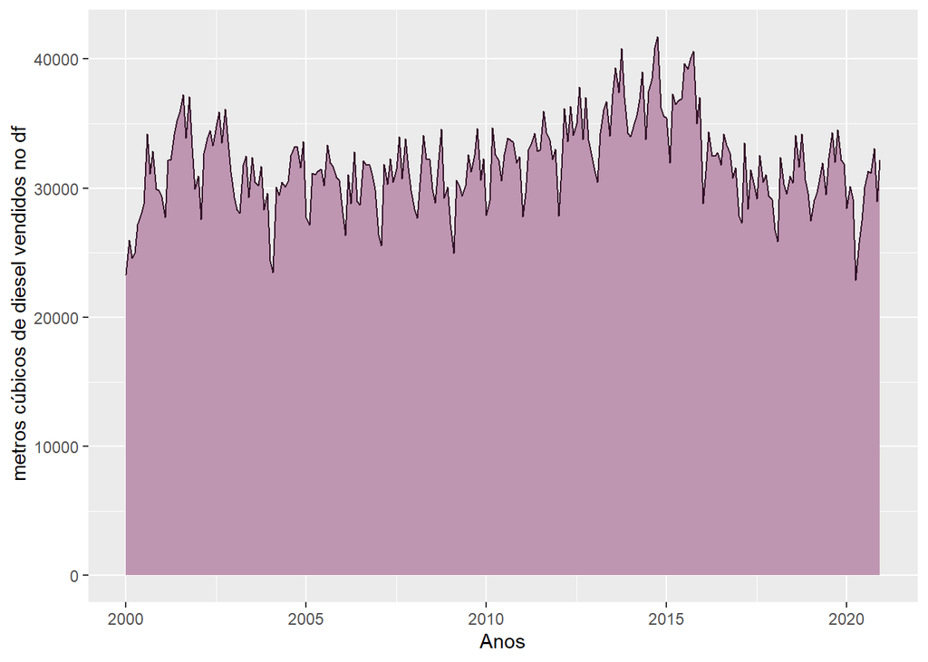

```r
df_total %>%
  ggplot()+
  geom_area(aes(x = ano, y = m3diesel), fill = "#be96b1", color = "#331228")+
  labs(x = "Anos", y = " metros cúbicos de diesel vendidos no df")
```

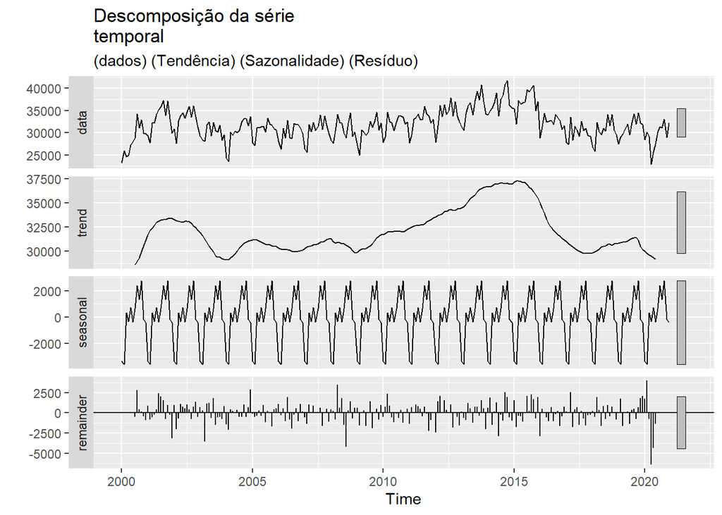

```r
df_serie <- ts(df_total[,3], start=2000, freq=12)

autoplot(decompose(df_serie,"additive")) + labs(title = "Descomposição da série
temporal", subtitle = "(dados) (Tendência) (Sazonalidade) (Resíduo)")
```

É possível observar que o consumo de diesel no Distrito Federal ao longo dos anos, no inicio de cada ano/ final do ano anterior, possui uma queda, caracterizando assim um período sazonal. Entre os anos de 2010 e 2015 houve uma tendência de crescimento porém a partir de 2016 há uma tendência de queda no consumo.

## Goiaz

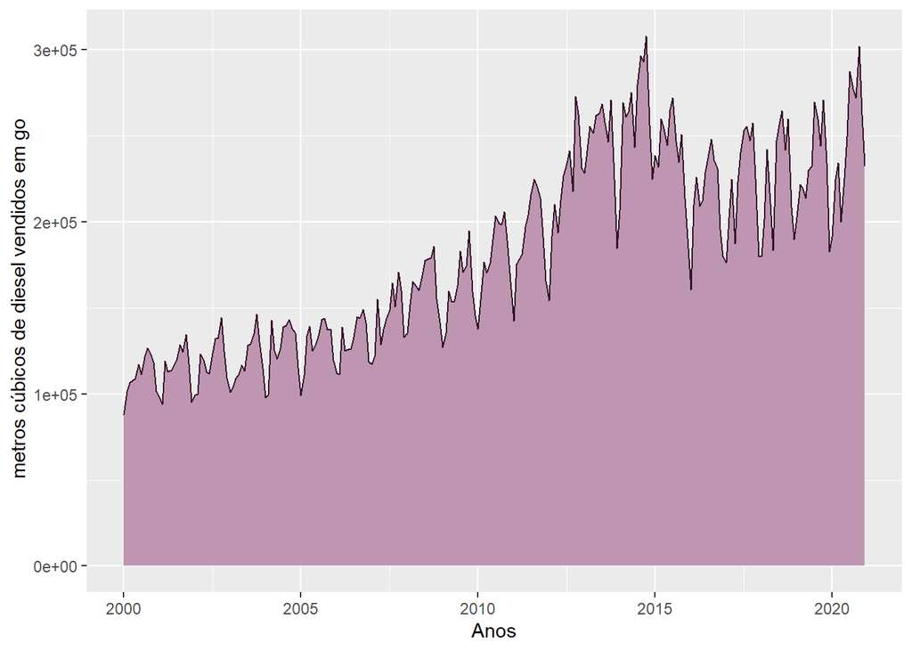

```r
go_total %>%
  ggplot()+
  geom_area(aes(x = ano, y = m3diesel), fill = "#be96b1", color = "#331228")+
  labs(x = "Anos", y = " metros cúbicos de diesel vendidos em go")
```

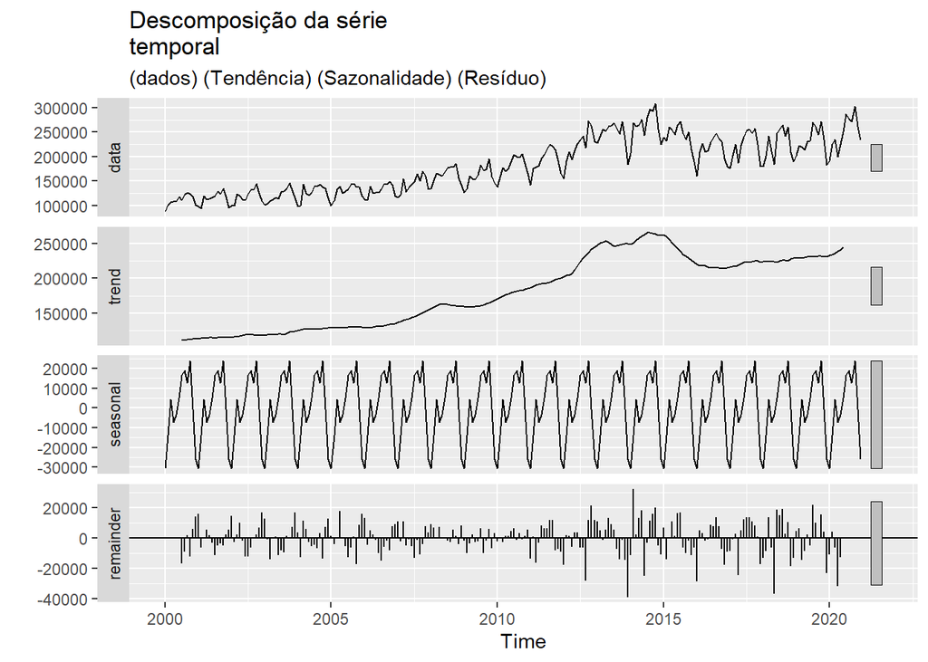

```r
go_serie <- ts(go_total[,3], start=2000, freq=12)

autoplot(decompose(go_serie,"additive")) + labs(title = "Descomposição da série
temporal", subtitle = "(dados) (Tendência) (Sazonalidade) (Resíduo)")
```

Podemos observar que em Goiaz durante os anos há uma queda sazonal do consumo de diesel no início de cada ano. Por volta do ano de 2007 o consumo de Diesel no estado vem seguindo uma tendência de crecimento que foi mais intenso no período de 2012 a 2015.

## Maranhão

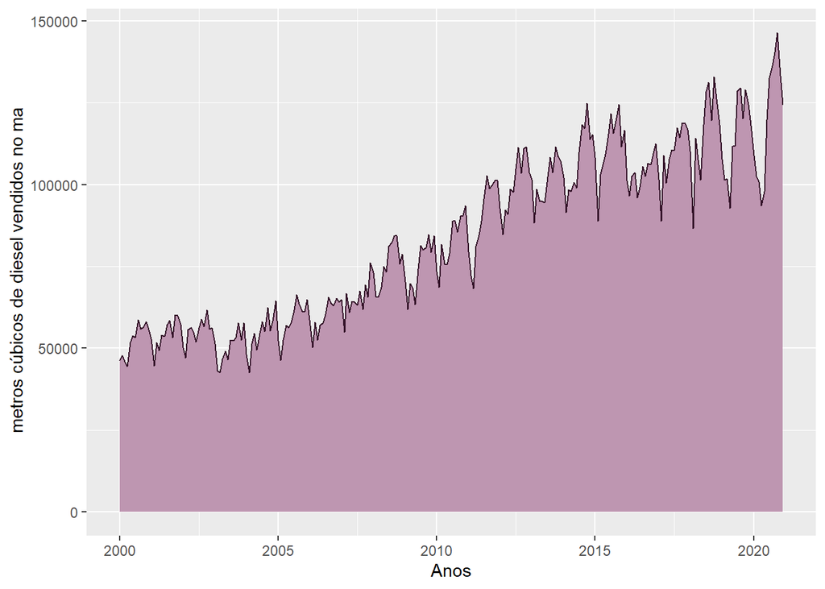

```r
ma_total %>%
  ggplot()+
  geom_area(aes(x = ano, y = m3diesel), fill = "#be96b1", color = "#331228")+
  labs(x = "Anos", y = " metros cúbicos de diesel vendidos no ma")
```

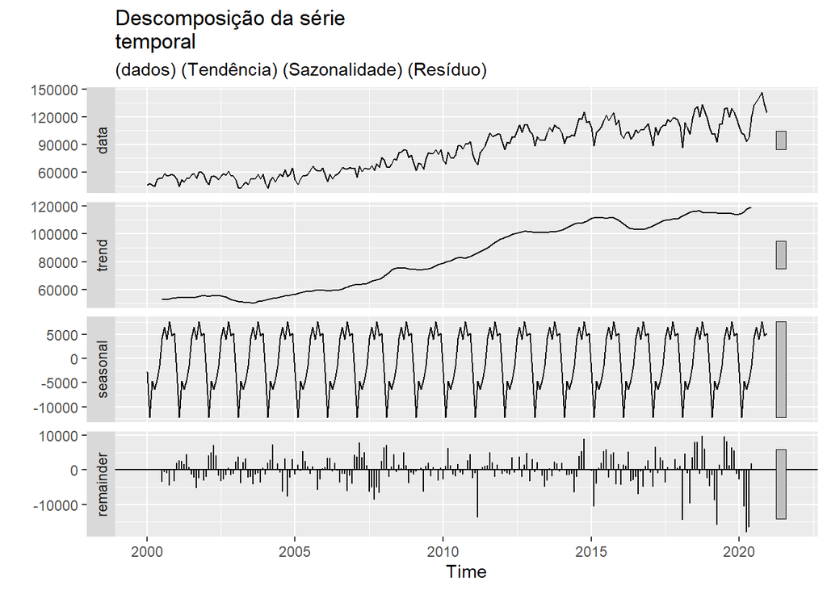

```r
ma_serie <- ts(ma_total[,3], start=2000, freq=12)

autoplot(decompose(ma_serie,"additive")) + labs(title = "Descomposição da série
temporal", subtitle = "(dados) (Tendência) (Sazonalidade) (Resíduo)")
```

No Maranhão observamos uma queda no consumo de Diesel no início de cada ano e logo a após grande alta no consumo ao longo de cada ano. Vemos ainda que apartir de 2007 há uma tendência de crescimento no consumo do diesel.

## Mato Grosso

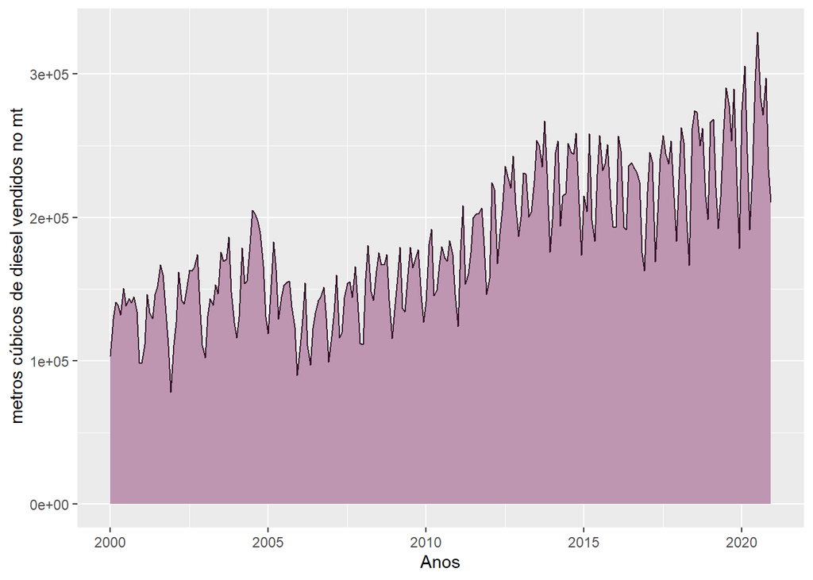

```r
mt_total %>%
  ggplot()+
  geom_area(aes(x = ano, y = m3diesel), fill = "#be96b1", color = "#331228")+
  labs(x = "Anos", y = " metros cúbicos de diesel vendidos no mt")
```

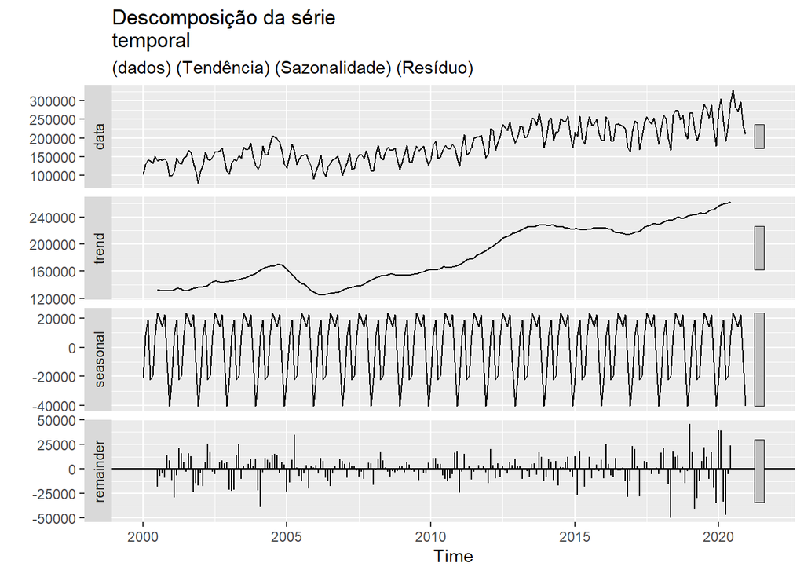

```r
mt_serie <- ts(mt_total[,3], start=2000, freq=12)

autoplot(decompose(mt_serie,"additive")) + labs(title = "Descomposição da série
temporal", subtitle = "(dados) (Tendência) (Sazonalidade) (Resíduo)")
```

Em Mato Grosso vemos queda no consumo de diesel no início do ano e no início de segundo trimestre de forma sazonal. Por volta de 2006 é possível observar uma tendência de crescimento

## Minas Gerais

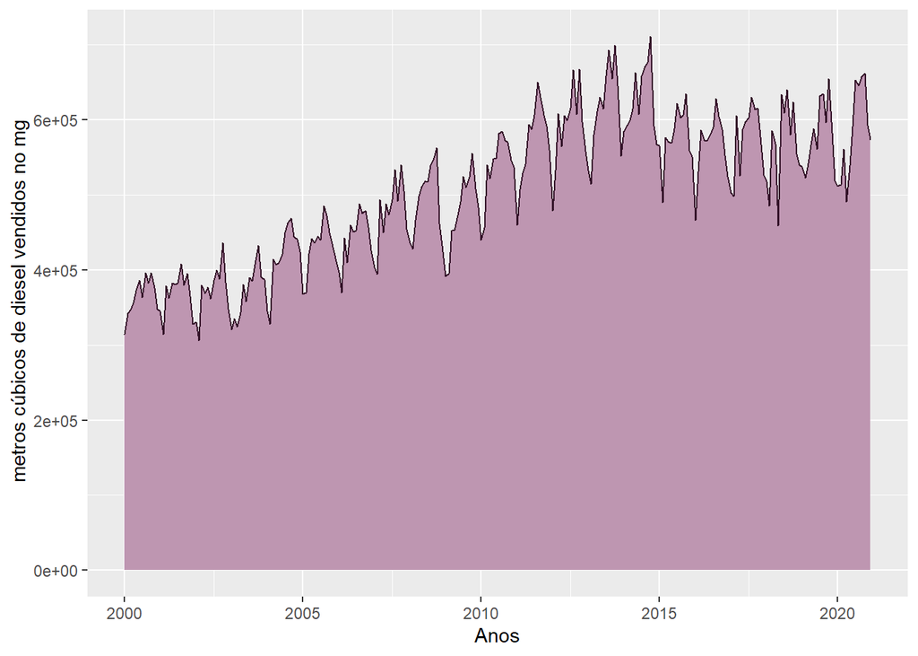

```r
mg_total %>%
  ggplot()+
  geom_area(aes(x = ano, y = m3diesel), fill = "#be96b1", color = "#331228")+
  labs(x = "Anos", y = " metros cúbicos de diesel vendidos no mg")
```

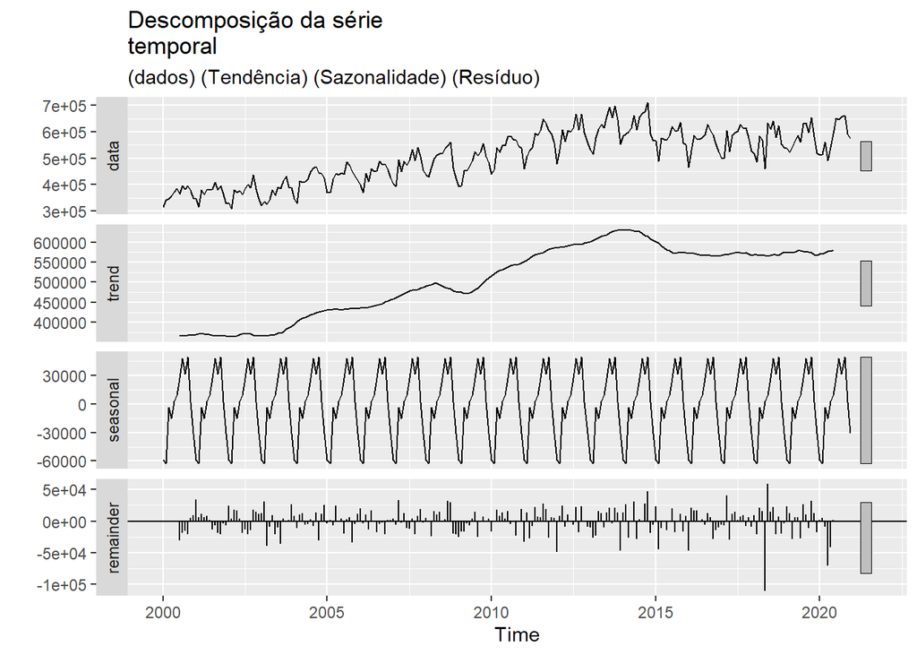

```r
mg_serie <- ts(mg_total[,3], start=2000, freq=12)

autoplot(decompose(mg_serie,"additive")) + labs(title = "Descomposição da série
temporal", subtitle = "(dados) (Tendência) (Sazonalidade) (Resíduo)")
```

Em Minas vemos o comportamento sazonal de queda no consumo de diesel no início de cada ano. Vemos também uma tendencia de crecimento no consumo.

## Pará

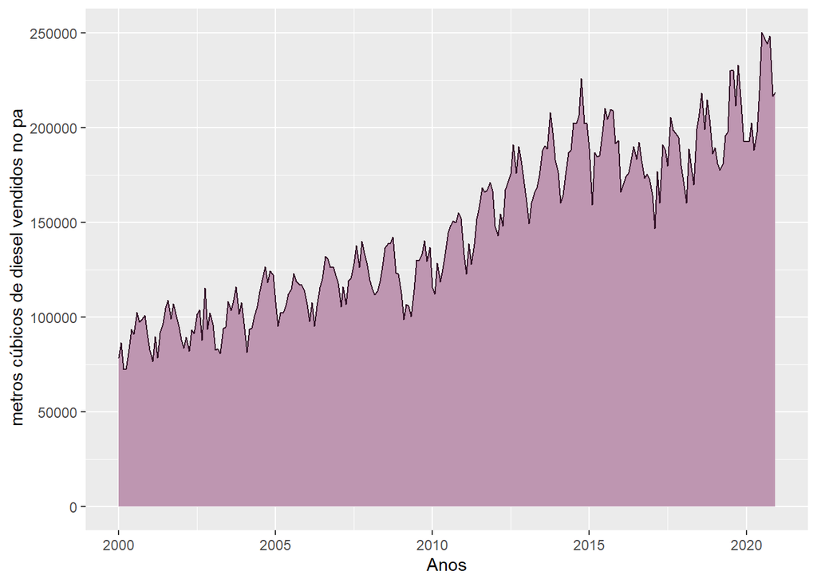

```r
pa_total %>%
  ggplot()+
  geom_area(aes(x = ano, y = m3diesel), fill = "#be96b1", color = "#331228")+
  labs(x = "Anos", y = " metros cúbicos de diesel vendidos no pa")
```

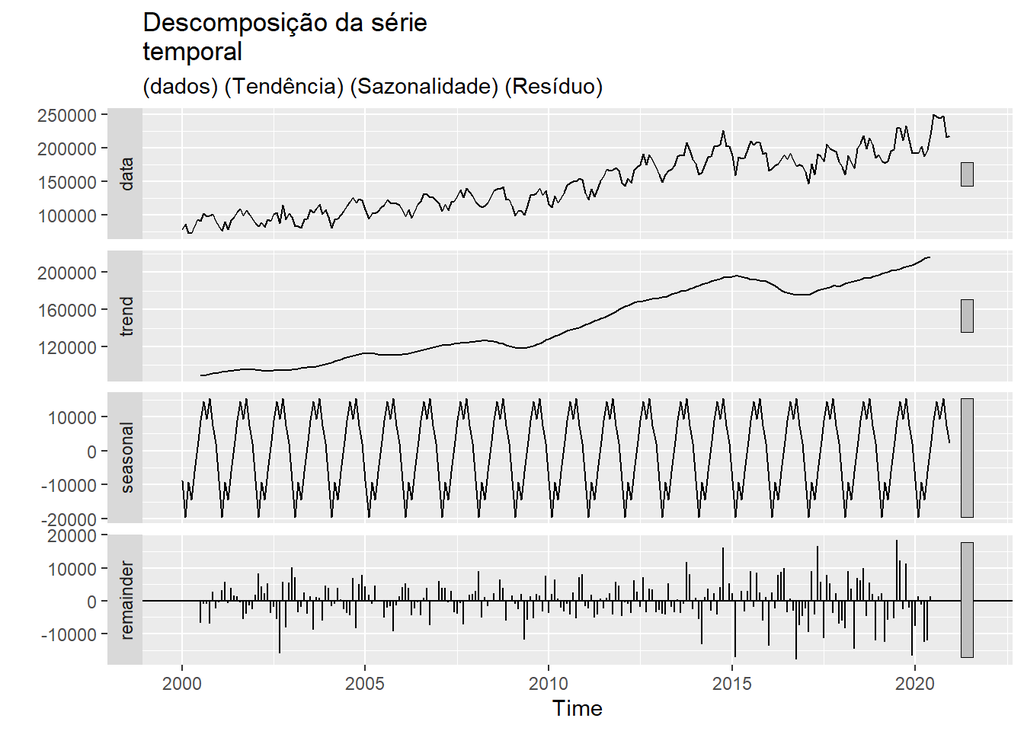

```r
pa_serie <- ts(pa_total[,3], start=2000, freq=12)

autoplot(decompose(pa_serie,"additive")) + labs(title = "Descomposição da série
temporal", subtitle = "(dados) (Tendência) (Sazonalidade) (Resíduo)")
```

## São Paulo

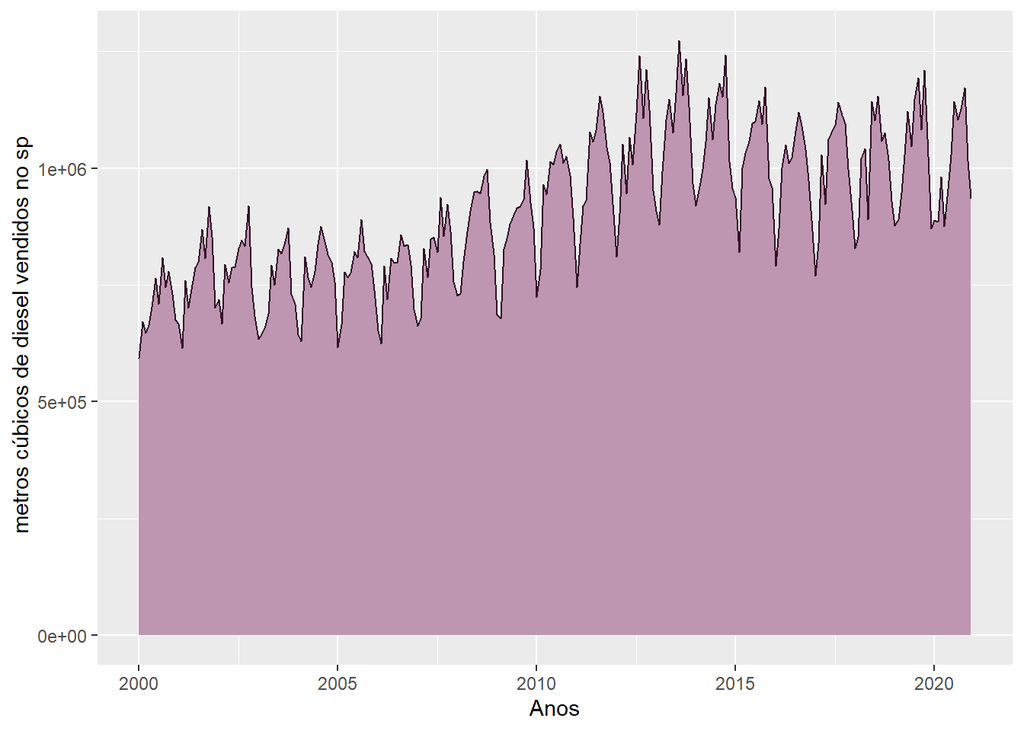

```r
sp_total %>%
  ggplot()+
  geom_area(aes(x = ano, y = m3diesel), fill = "#be96b1", color = "#331228")+
  labs(x = "Anos", y = " metros cúbicos de diesel vendidos no sp")
```

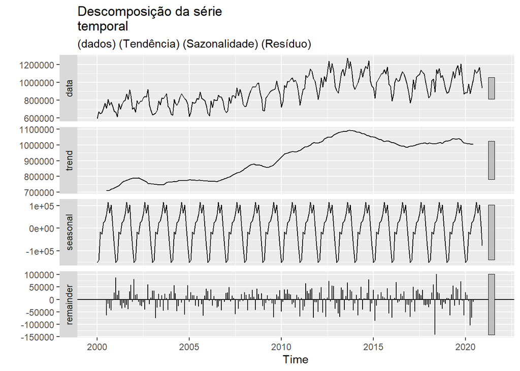

```r
sp_serie <- ts(sp_total[,3], start=2000, freq=12)

autoplot(decompose(sp_serie,"additive")) + labs(title = "Descomposição da série
temporal", subtitle = "(dados) (Tendência) (Sazonalidade) (Resíduo)")
```

## Tocantins

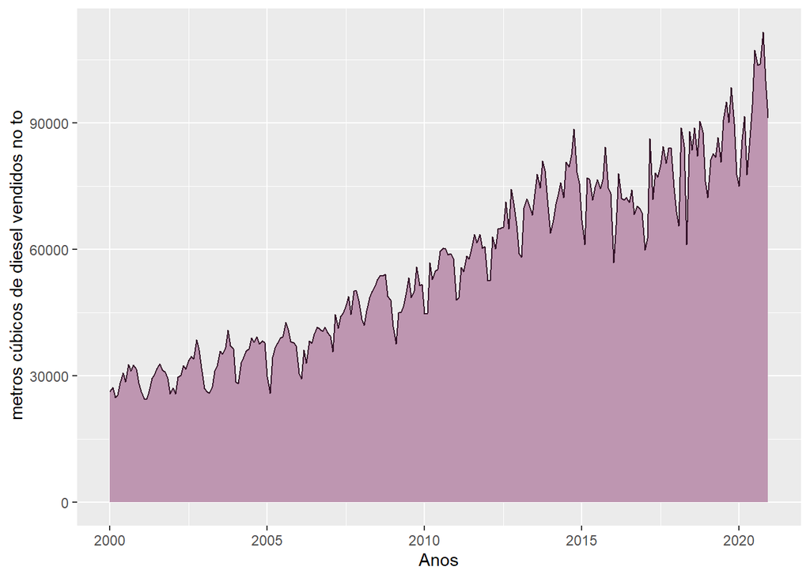

```r
to_total %>%
  ggplot()+
  geom_area(aes(x = ano, y = m3diesel), fill = "#be96b1", color = "#331228")+
  labs(x = "Anos", y = " metros cúbicos de diesel vendidos no to")
```

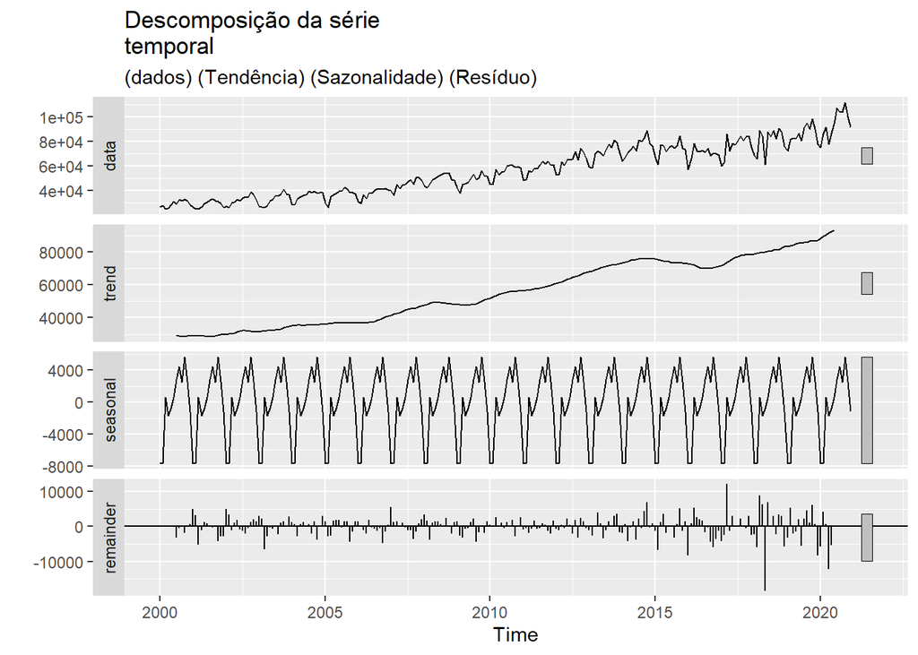

```r
to_serie <- ts(to_total[,3], start=2000, freq=12)

autoplot(decompose(to_serie,"additive")) + labs(title = "Descomposição da série
temporal", subtitle = "(dados) (Tendência) (Sazonalidade) (Resíduo)")
```

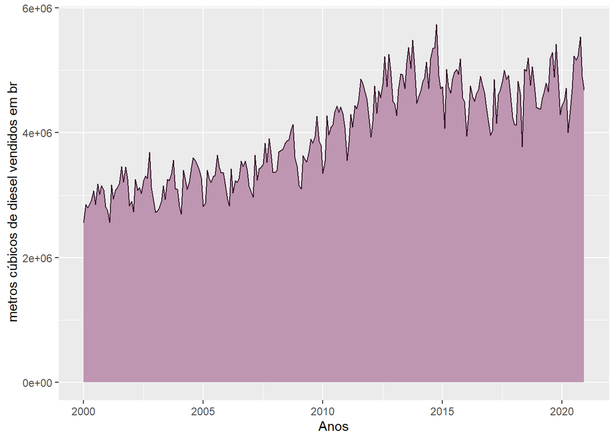

```r
br_total %>%
  ggplot()+
  geom_area(aes(x = ano, y = m3diesel), fill = "#be96b1", color = "#331228")+
  labs(x = "Anos", y = " metros cúbicos de diesel vendidos em br")
```

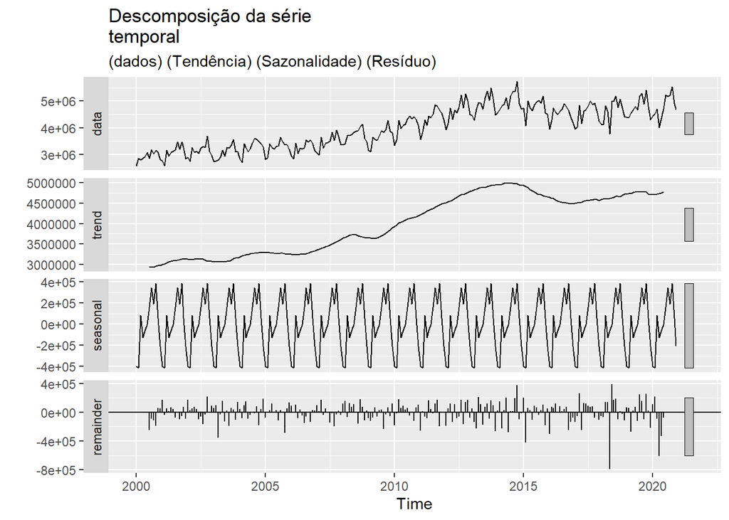

```r
br_serie <- ts(br_total[,3], start=2000, freq=12)

autoplot(decompose(br_serie,"additive")) + labs(title = "Descomposição da série
temporal", subtitle = "(dados) (Tendência) (Sazonalidade) (Resíduo)")
```

# Gasolina

```r
df0 <- gasolina%>% filter(regiao=="df")

df00 <- df0[,c(1,2,3)] %>% rename(m3diesel = "2000" )
df1 <- df0[,c(1,2,4)]  %>% rename(m3diesel = "2001" )
df2 <- df0[,c(1,2,5)]  %>% rename(m3diesel = "2002" )
df3 <- df0[,c(1,2,6)]  %>% rename(m3diesel = "2003" )
df4 <- df0[,c(1,2,7)]  %>% rename(m3diesel = "2004" )
df5 <- df0[,c(1,2,8)]  %>% rename(m3diesel = "2005" )
df6 <- df0[,c(1,2,9)]  %>% rename(m3diesel = "2006" )
df7 <- df0[,c(1,2,10)]  %>% rename(m3diesel = "2007" )
df8 <- df0[,c(1,2,11)]  %>% rename(m3diesel = "2008" )
df9 <- df0[,c(1,2,12)]  %>% rename(m3diesel = "2009" )
df10 <- df0[,c(1,2,13)]  %>% rename(m3diesel = "2010" )
df11 <- df0[,c(1,2,14)]  %>% rename(m3diesel = "2011" )
df12 <- df0[,c(1,2,15)]  %>% rename(m3diesel = "2012" )
df13 <- df0[,c(1,2,16)]  %>% rename(m3diesel = "2013" )
df14 <- df0[,c(1,2,17)]  %>% rename(m3diesel = "2014" )
df15 <- df0[,c(1,2,18)]  %>% rename(m3diesel = "2015" )
df16 <- df0[,c(1,2,19)]  %>% rename(m3diesel = "2016" )
df17 <- df0[,c(1,2,20)]  %>% rename(m3diesel = "2017" )
df18 <- df0[,c(1,2,21)]  %>% rename(m3diesel = "2018" )
df19 <- df0[,c(1,2,22)]  %>% rename(m3diesel = "2019" )
df20 <- df0[,c(1,2,23)]  %>% rename(m3diesel = "2020" )

df_total <- bind_rows(df00,df1,df2,df3,df4,df5,df6,df7,df8,df9,df10,df11,df12,df13,df14,df15,df16,df17,df18,df19,df20)
```

```r
require(lubridate)
ano <- seq.Date(from = as_date("2000-01-01"),
         to = as_date("2020-12-01"),
         by = "1 month")

df_total<- cbind(df_total,ano)
```

```r
df0 <- gasolina%>% filter(regiao=="go")

df00 <- df0[,c(1,2,3)] %>% rename(m3diesel = "2000" )
df1 <- df0[,c(1,2,4)]  %>% rename(m3diesel = "2001" )
df2 <- df0[,c(1,2,5)]  %>% rename(m3diesel = "2002" )
df3 <- df0[,c(1,2,6)]  %>% rename(m3diesel = "2003" )
df4 <- df0[,c(1,2,7)]  %>% rename(m3diesel = "2004" )
df5 <- df0[,c(1,2,8)]  %>% rename(m3diesel = "2005" )
df6 <- df0[,c(1,2,9)]  %>% rename(m3diesel = "2006" )
df7 <- df0[,c(1,2,10)]  %>% rename(m3diesel = "2007" )
df8 <- df0[,c(1,2,11)]  %>% rename(m3diesel = "2008" )
df9 <- df0[,c(1,2,12)]  %>% rename(m3diesel = "2009" )
df10 <- df0[,c(1,2,13)]  %>% rename(m3diesel = "2010" )
df11 <- df0[,c(1,2,14)]  %>% rename(m3diesel = "2011" )
df12 <- df0[,c(1,2,15)]  %>% rename(m3diesel = "2012" )
df13 <- df0[,c(1,2,16)]  %>% rename(m3diesel = "2013" )
df14 <- df0[,c(1,2,17)]  %>% rename(m3diesel = "2014" )
df15 <- df0[,c(1,2,18)]  %>% rename(m3diesel = "2015" )
df16 <- df0[,c(1,2,19)]  %>% rename(m3diesel = "2016" )
df17 <- df0[,c(1,2,20)]  %>% rename(m3diesel = "2017" )
df18 <- df0[,c(1,2,21)]  %>% rename(m3diesel = "2018" )
df19 <- df0[,c(1,2,22)]  %>% rename(m3diesel = "2019" )
df20 <- df0[,c(1,2,23)]  %>% rename(m3diesel = "2020" )

go_total <- bind_rows(df00,df1,df2,df3,df4,df5,df6,df7,df8,df9,df10,df11,df12,df13,df14,df15,df16,df17,df18,df19,df20)
go_total<- cbind(go_total,ano)
```

```r
df0 <- gasolina%>% filter(regiao=="ma")

df00 <- df0[,c(1,2,3)] %>% rename(m3diesel = "2000" )
df1 <- df0[,c(1,2,4)]  %>% rename(m3diesel = "2001" )
df2 <- df0[,c(1,2,5)]  %>% rename(m3diesel = "2002" )
df3 <- df0[,c(1,2,6)]  %>% rename(m3diesel = "2003" )
df4 <- df0[,c(1,2,7)]  %>% rename(m3diesel = "2004" )
df5 <- df0[,c(1,2,8)]  %>% rename(m3diesel = "2005" )
df6 <- df0[,c(1,2,9)]  %>% rename(m3diesel = "2006" )
df7 <- df0[,c(1,2,10)]  %>% rename(m3diesel = "2007" )
df8 <- df0[,c(1,2,11)]  %>% rename(m3diesel = "2008" )
df9 <- df0[,c(1,2,12)]  %>% rename(m3diesel = "2009" )
df10 <- df0[,c(1,2,13)]  %>% rename(m3diesel = "2010" )
df11 <- df0[,c(1,2,14)]  %>% rename(m3diesel = "2011" )
df12 <- df0[,c(1,2,15)]  %>% rename(m3diesel = "2012" )
df13 <- df0[,c(1,2,16)]  %>% rename(m3diesel = "2013" )
df14 <- df0[,c(1,2,17)]  %>% rename(m3diesel = "2014" )
df15 <- df0[,c(1,2,18)]  %>% rename(m3diesel = "2015" )
df16 <- df0[,c(1,2,19)]  %>% rename(m3diesel = "2016" )
df17 <- df0[,c(1,2,20)]  %>% rename(m3diesel = "2017" )
df18 <- df0[,c(1,2,21)]  %>% rename(m3diesel = "2018" )
df19 <- df0[,c(1,2,22)]  %>% rename(m3diesel = "2019" )
df20 <- df0[,c(1,2,23)]  %>% rename(m3diesel = "2020" )

ma_total <- bind_rows(df00,df1,df2,df3,df4,df5,df6,df7,df8,df9,df10,df11,df12,df13,df14,df15,df16,df17,df18,df19,df20)
ma_total<- cbind(ma_total,ano)
```

```r
df0 <- gasolina%>% filter(regiao=="mt")

df00 <- df0[,c(1,2,3)] %>% rename(m3diesel = "2000" )
df1 <- df0[,c(1,2,4)]  %>% rename(m3diesel = "2001" )
df2 <- df0[,c(1,2,5)]  %>% rename(m3diesel = "2002" )
df3 <- df0[,c(1,2,6)]  %>% rename(m3diesel = "2003" )
df4 <- df0[,c(1,2,7)]  %>% rename(m3diesel = "2004" )
df5 <- df0[,c(1,2,8)]  %>% rename(m3diesel = "2005" )
df6 <- df0[,c(1,2,9)]  %>% rename(m3diesel = "2006" )
df7 <- df0[,c(1,2,10)]  %>% rename(m3diesel = "2007" )
df8 <- df0[,c(1,2,11)]  %>% rename(m3diesel = "2008" )
df9 <- df0[,c(1,2,12)]  %>% rename(m3diesel = "2009" )
df10 <- df0[,c(1,2,13)]  %>% rename(m3diesel = "2010" )
df11 <- df0[,c(1,2,14)]  %>% rename(m3diesel = "2011" )
df12 <- df0[,c(1,2,15)]  %>% rename(m3diesel = "2012" )
df13 <- df0[,c(1,2,16)]  %>% rename(m3diesel = "2013" )
df14 <- df0[,c(1,2,17)]  %>% rename(m3diesel = "2014" )
df15 <- df0[,c(1,2,18)]  %>% rename(m3diesel = "2015" )
df16 <- df0[,c(1,2,19)]  %>% rename(m3diesel = "2016" )
df17 <- df0[,c(1,2,20)]  %>% rename(m3diesel = "2017" )
df18 <- df0[,c(1,2,21)]  %>% rename(m3diesel = "2018" )
df19 <- df0[,c(1,2,22)]  %>% rename(m3diesel = "2019" )
df20 <- df0[,c(1,2,23)]  %>% rename(m3diesel = "2020" )

mt_total <- bind_rows(df00,df1,df2,df3,df4,df5,df6,df7,df8,df9,df10,df11,df12,df13,df14,df15,df16,df17,df18,df19,df20)
mt_total<- cbind(mt_total,ano)
```

```r
df0 <- gasolina%>% filter(regiao=="mg")

df00 <- df0[,c(1,2,3)] %>% rename(m3diesel = "2000" )
df1 <- df0[,c(1,2,4)]  %>% rename(m3diesel = "2001" )
df2 <- df0[,c(1,2,5)]  %>% rename(m3diesel = "2002" )
df3 <- df0[,c(1,2,6)]  %>% rename(m3diesel = "2003" )
df4 <- df0[,c(1,2,7)]  %>% rename(m3diesel = "2004" )
df5 <- df0[,c(1,2,8)]  %>% rename(m3diesel = "2005" )
df6 <- df0[,c(1,2,9)]  %>% rename(m3diesel = "2006" )
df7 <- df0[,c(1,2,10)]  %>% rename(m3diesel = "2007" )
df8 <- df0[,c(1,2,11)]  %>% rename(m3diesel = "2008" )
df9 <- df0[,c(1,2,12)]  %>% rename(m3diesel = "2009" )
df10 <- df0[,c(1,2,13)]  %>% rename(m3diesel = "2010" )
df11 <- df0[,c(1,2,14)]  %>% rename(m3diesel = "2011" )
df12 <- df0[,c(1,2,15)]  %>% rename(m3diesel = "2012" )
df13 <- df0[,c(1,2,16)]  %>% rename(m3diesel = "2013" )
df14 <- df0[,c(1,2,17)]  %>% rename(m3diesel = "2014" )
df15 <- df0[,c(1,2,18)]  %>% rename(m3diesel = "2015" )
df16 <- df0[,c(1,2,19)]  %>% rename(m3diesel = "2016" )
df17 <- df0[,c(1,2,20)]  %>% rename(m3diesel = "2017" )
df18 <- df0[,c(1,2,21)]  %>% rename(m3diesel = "2018" )
df19 <- df0[,c(1,2,22)]  %>% rename(m3diesel = "2019" )
df20 <- df0[,c(1,2,23)]  %>% rename(m3diesel = "2020" )

mg_total <- bind_rows(df00,df1,df2,df3,df4,df5,df6,df7,df8,df9,df10,df11,df12,df13,df14,df15,df16,df17,df18,df19,df20)
mg_total<- cbind(mg_total,ano)
```

```r
df0 <- gasolina%>% filter(regiao=="pa")

df00 <- df0[,c(1,2,3)] %>% rename(m3diesel = "2000" )
df1 <- df0[,c(1,2,4)]  %>% rename(m3diesel = "2001" )
df2 <- df0[,c(1,2,5)]  %>% rename(m3diesel = "2002" )
df3 <- df0[,c(1,2,6)]  %>% rename(m3diesel = "2003" )
df4 <- df0[,c(1,2,7)]  %>% rename(m3diesel = "2004" )
df5 <- df0[,c(1,2,8)]  %>% rename(m3diesel = "2005" )
df6 <- df0[,c(1,2,9)]  %>% rename(m3diesel = "2006" )
df7 <- df0[,c(1,2,10)]  %>% rename(m3diesel = "2007" )
df8 <- df0[,c(1,2,11)]  %>% rename(m3diesel = "2008" )
df9 <- df0[,c(1,2,12)]  %>% rename(m3diesel = "2009" )
df10 <- df0[,c(1,2,13)]  %>% rename(m3diesel = "2010" )
df11 <- df0[,c(1,2,14)]  %>% rename(m3diesel = "2011" )
df12 <- df0[,c(1,2,15)]  %>% rename(m3diesel = "2012" )
df13 <- df0[,c(1,2,16)]  %>% rename(m3diesel = "2013" )
df14 <- df0[,c(1,2,17)]  %>% rename(m3diesel = "2014" )
df15 <- df0[,c(1,2,18)]  %>% rename(m3diesel = "2015" )
df16 <- df0[,c(1,2,19)]  %>% rename(m3diesel = "2016" )
df17 <- df0[,c(1,2,20)]  %>% rename(m3diesel = "2017" )
df18 <- df0[,c(1,2,21)]  %>% rename(m3diesel = "2018" )
df19 <- df0[,c(1,2,22)]  %>% rename(m3diesel = "2019" )
df20 <- df0[,c(1,2,23)]  %>% rename(m3diesel = "2020" )

pa_total <- bind_rows(df00,df1,df2,df3,df4,df5,df6,df7,df8,df9,df10,df11,df12,df13,df14,df15,df16,df17,df18,df19,df20)
pa_total<- cbind(pa_total,ano)
```

```r
df0 <- gasolina%>% filter(regiao=="sp")

df00 <- df0[,c(1,2,3)] %>% rename(m3diesel = "2000" )
df1 <- df0[,c(1,2,4)]  %>% rename(m3diesel = "2001" )
df2 <- df0[,c(1,2,5)]  %>% rename(m3diesel = "2002" )
df3 <- df0[,c(1,2,6)]  %>% rename(m3diesel = "2003" )
df4 <- df0[,c(1,2,7)]  %>% rename(m3diesel = "2004" )
df5 <- df0[,c(1,2,8)]  %>% rename(m3diesel = "2005" )
df6 <- df0[,c(1,2,9)]  %>% rename(m3diesel = "2006" )
df7 <- df0[,c(1,2,10)]  %>% rename(m3diesel = "2007" )
df8 <- df0[,c(1,2,11)]  %>% rename(m3diesel = "2008" )
df9 <- df0[,c(1,2,12)]  %>% rename(m3diesel = "2009" )
df10 <- df0[,c(1,2,13)]  %>% rename(m3diesel = "2010" )
df11 <- df0[,c(1,2,14)]  %>% rename(m3diesel = "2011" )
df12 <- df0[,c(1,2,15)]  %>% rename(m3diesel = "2012" )
df13 <- df0[,c(1,2,16)]  %>% rename(m3diesel = "2013" )
df14 <- df0[,c(1,2,17)]  %>% rename(m3diesel = "2014" )
df15 <- df0[,c(1,2,18)]  %>% rename(m3diesel = "2015" )
df16 <- df0[,c(1,2,19)]  %>% rename(m3diesel = "2016" )
df17 <- df0[,c(1,2,20)]  %>% rename(m3diesel = "2017" )
df18 <- df0[,c(1,2,21)]  %>% rename(m3diesel = "2018" )
df19 <- df0[,c(1,2,22)]  %>% rename(m3diesel = "2019" )
df20 <- df0[,c(1,2,23)]  %>% rename(m3diesel = "2020" )

sp_total <- bind_rows(df00,df1,df2,df3,df4,df5,df6,df7,df8,df9,df10,df11,df12,df13,df14,df15,df16,df17,df18,df19,df20)
sp_total<- cbind(sp_total,ano)
```

```r
df0 <- gasolina%>% filter(regiao=="to")

df00 <- df0[,c(1,2,3)] %>% rename(m3diesel = "2000" )
df1 <- df0[,c(1,2,4)]  %>% rename(m3diesel = "2001" )
df2 <- df0[,c(1,2,5)]  %>% rename(m3diesel = "2002" )
df3 <- df0[,c(1,2,6)]  %>% rename(m3diesel = "2003" )
df4 <- df0[,c(1,2,7)]  %>% rename(m3diesel = "2004" )
df5 <- df0[,c(1,2,8)]  %>% rename(m3diesel = "2005" )
df6 <- df0[,c(1,2,9)]  %>% rename(m3diesel = "2006" )
df7 <- df0[,c(1,2,10)]  %>% rename(m3diesel = "2007" )
df8 <- df0[,c(1,2,11)]  %>% rename(m3diesel = "2008" )
df9 <- df0[,c(1,2,12)]  %>% rename(m3diesel = "2009" )
df10 <- df0[,c(1,2,13)]  %>% rename(m3diesel = "2010" )
df11 <- df0[,c(1,2,14)]  %>% rename(m3diesel = "2011" )
df12 <- df0[,c(1,2,15)]  %>% rename(m3diesel = "2012" )
df13 <- df0[,c(1,2,16)]  %>% rename(m3diesel = "2013" )
df14 <- df0[,c(1,2,17)]  %>% rename(m3diesel = "2014" )
df15 <- df0[,c(1,2,18)]  %>% rename(m3diesel = "2015" )
df16 <- df0[,c(1,2,19)]  %>% rename(m3diesel = "2016" )
df17 <- df0[,c(1,2,20)]  %>% rename(m3diesel = "2017" )
df18 <- df0[,c(1,2,21)]  %>% rename(m3diesel = "2018" )
df19 <- df0[,c(1,2,22)]  %>% rename(m3diesel = "2019" )
df20 <- df0[,c(1,2,23)]  %>% rename(m3diesel = "2020" )

to_total <- bind_rows(df00,df1,df2,df3,df4,df5,df6,df7,df8,df9,df10,df11,df12,df13,df14,df15,df16,df17,df18,df19,df20)
to_total<- cbind(to_total,ano)
```

```r
df0 <- gasolina%>% filter(regiao=="br")

df00 <- df0[,c(1,2,3)] %>% rename(m3diesel = "2000" )
df1 <- df0[,c(1,2,4)]  %>% rename(m3diesel = "2001" )
df2 <- df0[,c(1,2,5)]  %>% rename(m3diesel = "2002" )
df3 <- df0[,c(1,2,6)]  %>% rename(m3diesel = "2003" )
df4 <- df0[,c(1,2,7)]  %>% rename(m3diesel = "2004" )
df5 <- df0[,c(1,2,8)]  %>% rename(m3diesel = "2005" )
df6 <- df0[,c(1,2,9)]  %>% rename(m3diesel = "2006" )
df7 <- df0[,c(1,2,10)]  %>% rename(m3diesel = "2007" )
df8 <- df0[,c(1,2,11)]  %>% rename(m3diesel = "2008" )
df9 <- df0[,c(1,2,12)]  %>% rename(m3diesel = "2009" )
df10 <- df0[,c(1,2,13)]  %>% rename(m3diesel = "2010" )
df11 <- df0[,c(1,2,14)]  %>% rename(m3diesel = "2011" )
df12 <- df0[,c(1,2,15)]  %>% rename(m3diesel = "2012" )
df13 <- df0[,c(1,2,16)]  %>% rename(m3diesel = "2013" )
df14 <- df0[,c(1,2,17)]  %>% rename(m3diesel = "2014" )
df15 <- df0[,c(1,2,18)]  %>% rename(m3diesel = "2015" )
df16 <- df0[,c(1,2,19)]  %>% rename(m3diesel = "2016" )
df17 <- df0[,c(1,2,20)]  %>% rename(m3diesel = "2017" )
df18 <- df0[,c(1,2,21)]  %>% rename(m3diesel = "2018" )
df19 <- df0[,c(1,2,22)]  %>% rename(m3diesel = "2019" )
df20 <- df0[,c(1,2,23)]  %>% rename(m3diesel = "2020" )

br_total <- bind_rows(df00,df1,df2,df3,df4,df5,df6,df7,df8,df9,df10,df11,df12,df13,df14,df15,df16,df17,df18,df19,df20)
br_total<- cbind(br_total,ano)
```

## Distrito Federal

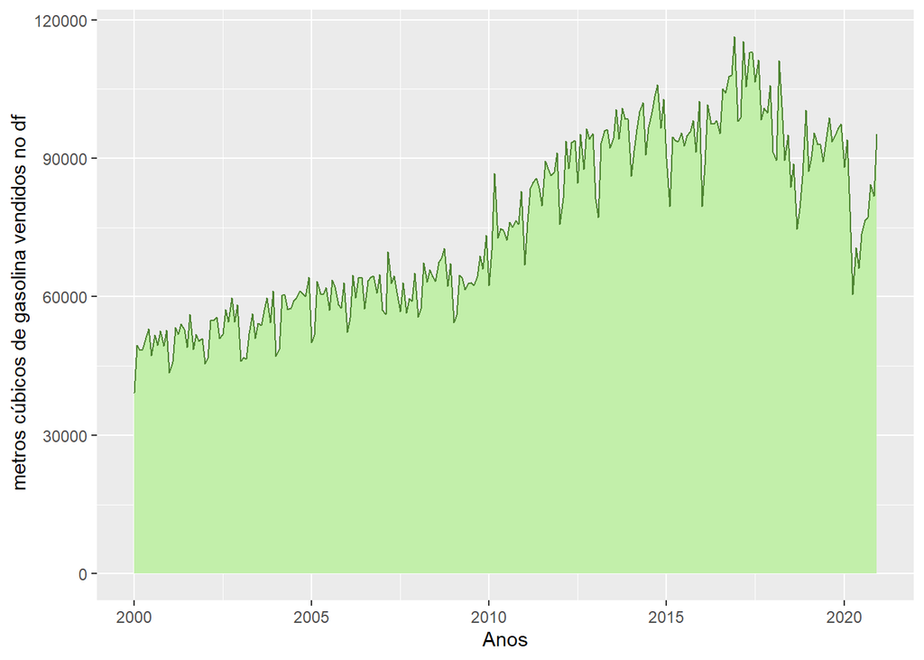

```r
df_total %>%
  ggplot()+
  geom_area(aes(x = ano, y = m3diesel), fill = "#c2efaa", color = "#4f8533")+
  labs(x = "Anos", y = " metros cúbicos de gasolina vendidos no df")
```

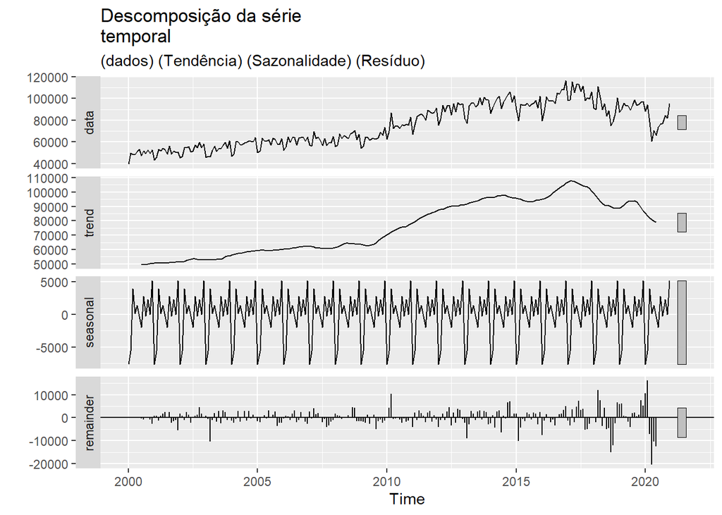

```r
df_serie <- ts(df_total[,3], start=2000, freq=12)

autoplot(decompose(df_serie,"additive")) + labs(title = "Descomposição da série
temporal", subtitle = "(dados) (Tendência) (Sazonalidade) (Resíduo)")
```

## Goiaz

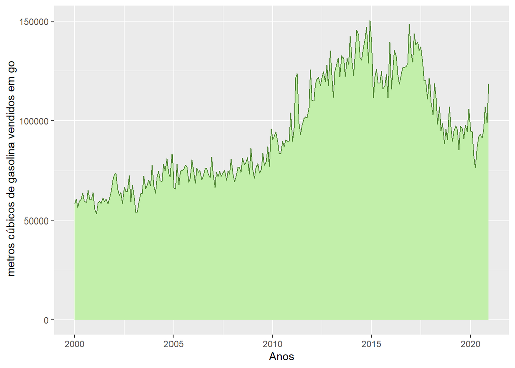

```r
go_total %>%
  ggplot()+
  geom_area(aes(x = ano, y = m3diesel), fill = "#c2efaa", color = "#4f8533")+
  labs(x = "Anos", y = " metros cúbicos de gasolina vendidos em go")
```

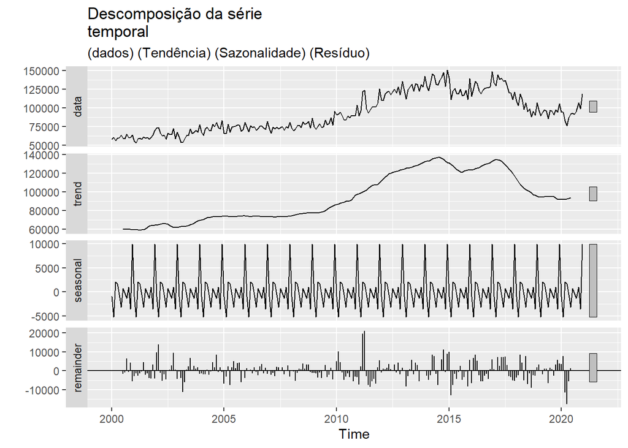

```r
go_serie <- ts(go_total[,3], start=2000, freq=12)

autoplot(decompose(go_serie,"additive")) + labs(title = "Descomposição da série
temporal", subtitle = "(dados) (Tendência) (Sazonalidade) (Resíduo)")
```

## Maranhão

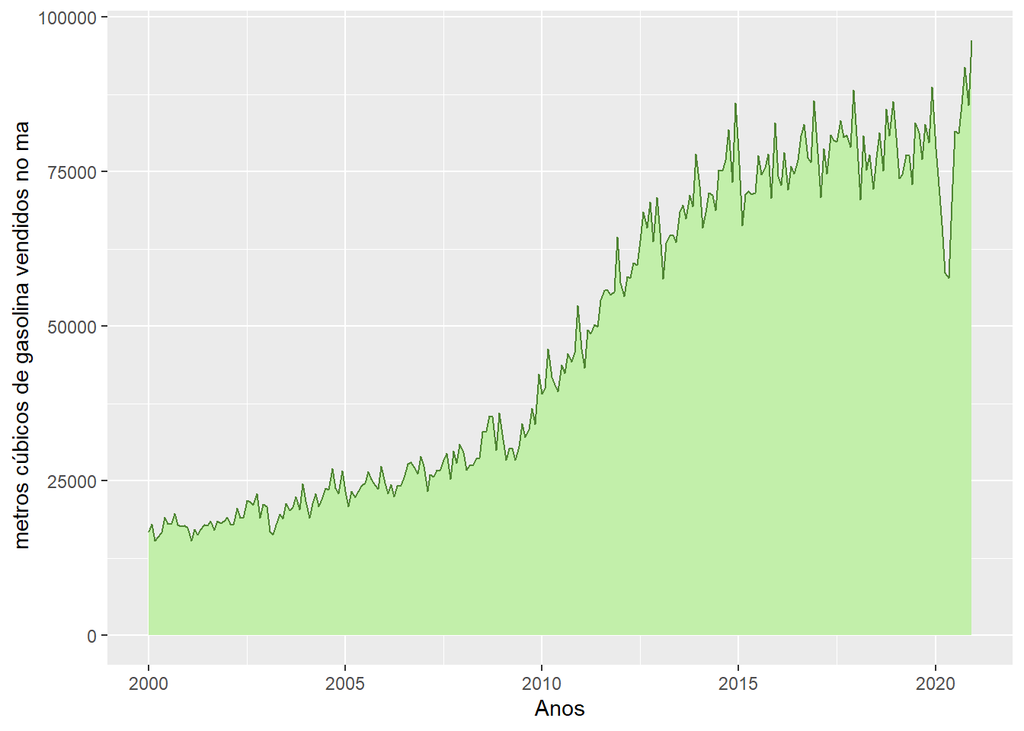

```r
ma_total %>%
  ggplot()+
  geom_area(aes(x = ano, y = m3diesel), fill = "#c2efaa", color = "#4f8533")+
  labs(x = "Anos", y = " metros cúbicos de gasolina vendidos no ma")
```

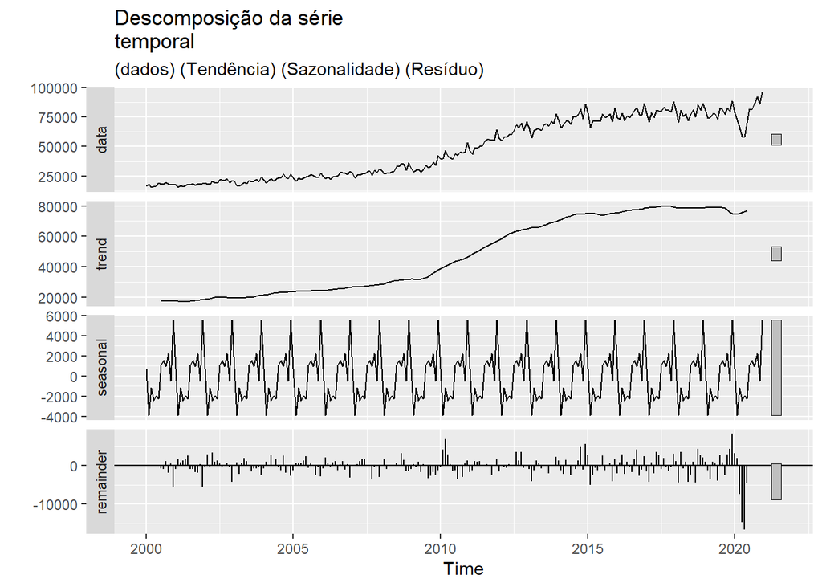

```r
ma_serie <- ts(ma_total[,3], start=2000, freq=12)

autoplot(decompose(ma_serie,"additive")) + labs(title = "Descomposição da série
temporal", subtitle = "(dados) (Tendência) (Sazonalidade) (Resíduo)")
```

## Mato Grosso

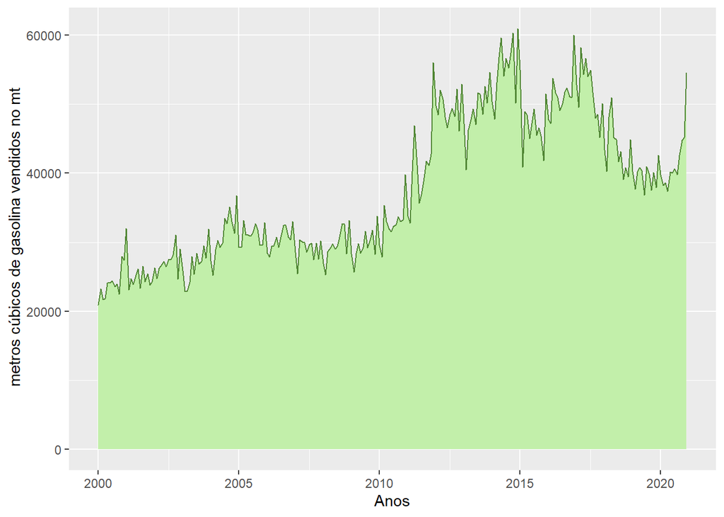

```r
mt_total %>%
  ggplot()+
  geom_area(aes(x = ano, y = m3diesel), fill = "#c2efaa", color = "#4f8533")+
  labs(x = "Anos", y = " metros cúbicos de gasolina vendidos no mt")
```

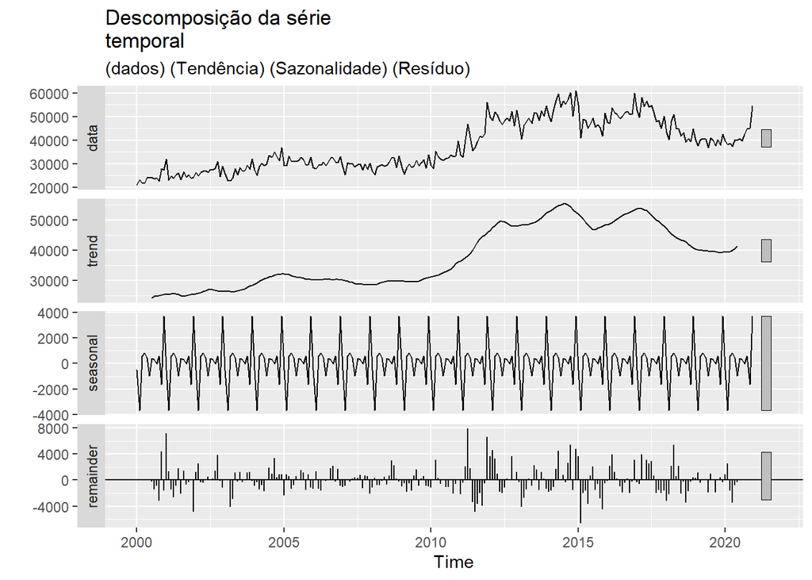

```r
mt_serie <- ts(mt_total[,3], start=2000, freq=12)

autoplot(decompose(mt_serie,"additive")) + labs(title = "Descomposição da série
temporal", subtitle = "(dados) (Tendência) (Sazonalidade) (Resíduo)")
```

## Minas Gerais

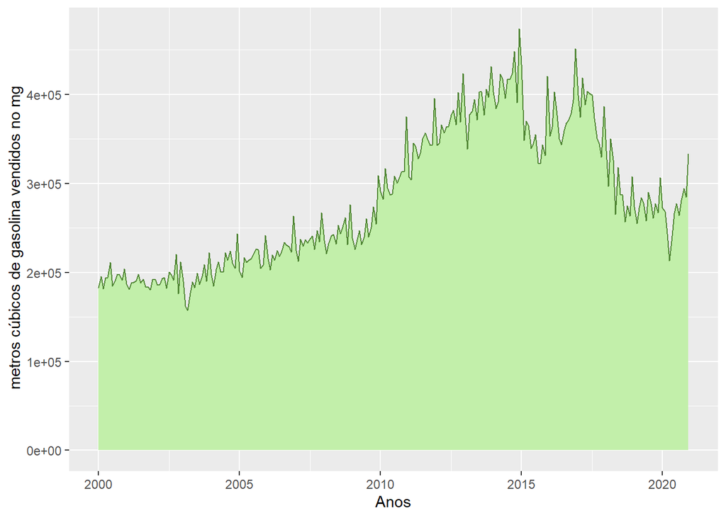

```r
mg_total %>%
  ggplot()+
  geom_area(aes(x = ano, y = m3diesel), fill = "#c2efaa", color = "#4f8533")+
  labs(x = "Anos", y = " metros cúbicos de gasolina vendidos no mg")
```

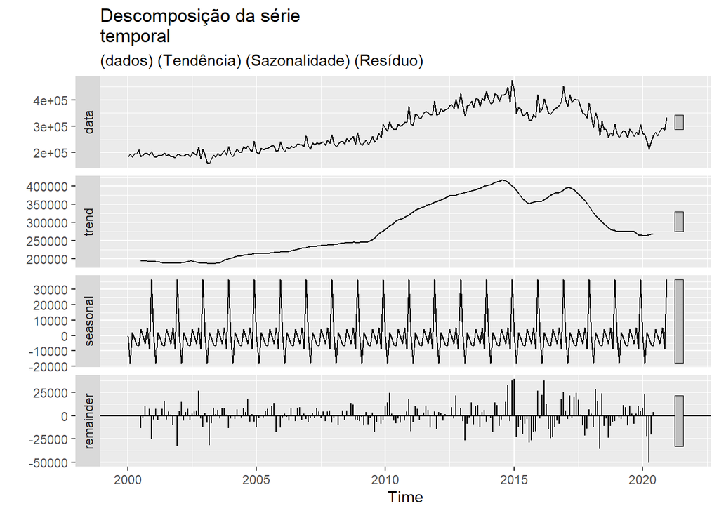

```r
mg_serie <- ts(mg_total[,3], start=2000, freq=12)

autoplot(decompose(mg_serie,"additive")) + labs(title = "Descomposição da série
temporal", subtitle = "(dados) (Tendência) (Sazonalidade) (Resíduo)")
```

## Pará

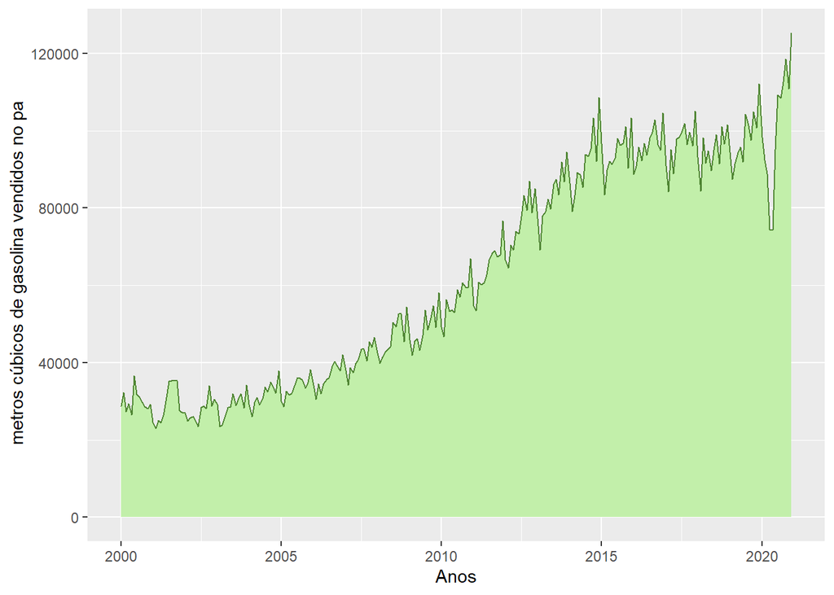

```r
pa_total %>%
  ggplot()+
  geom_area(aes(x = ano, y = m3diesel), fill = "#c2efaa", color = "#4f8533")+
  labs(x = "Anos", y = " metros cúbicos de gasolina vendidos no pa")
```

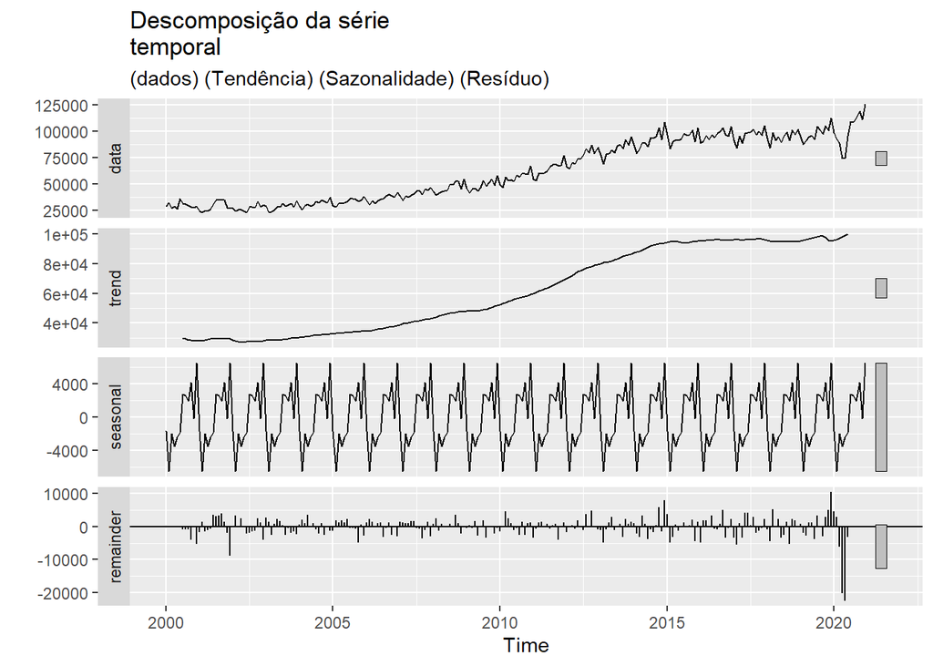

```r
pa_serie <- ts(pa_total[,3], start=2000, freq=12)

autoplot(decompose(pa_serie,"additive")) + labs(title = "Descomposição da série
temporal", subtitle = "(dados) (Tendência) (Sazonalidade) (Resíduo)")
```

## São Paulo

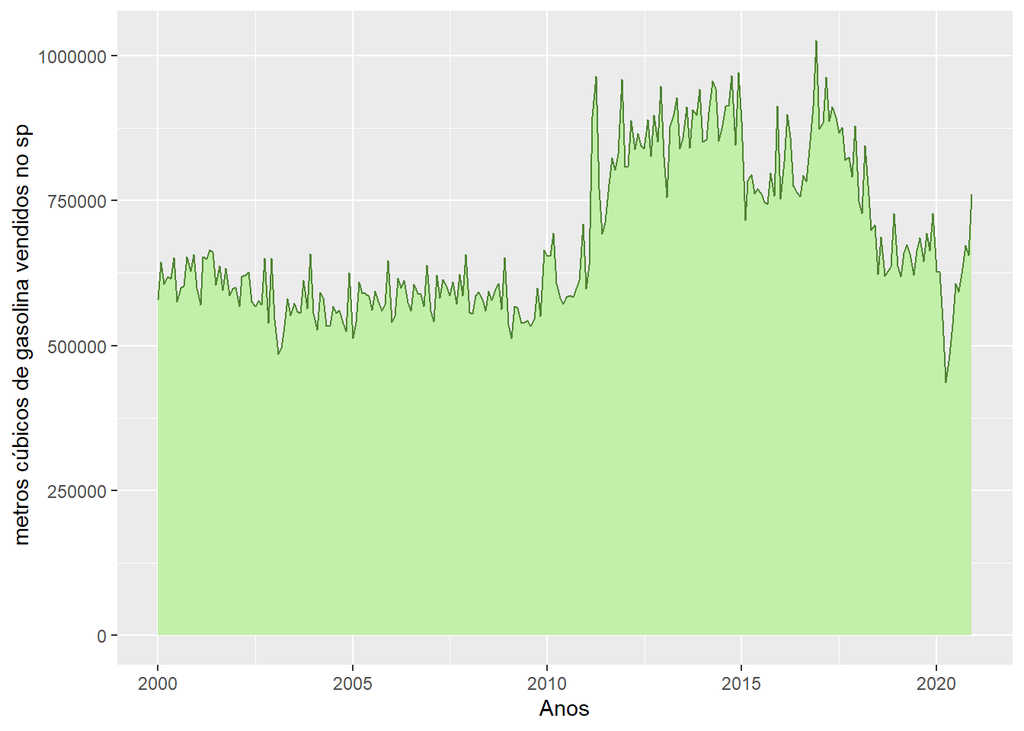

```r
sp_total %>%
  ggplot()+
  geom_area(aes(x = ano, y = m3diesel), fill = "#c2efaa", color = "#4f8533")+
  labs(x = "Anos", y = " metros cúbicos de gasolina vendidos no sp")
```

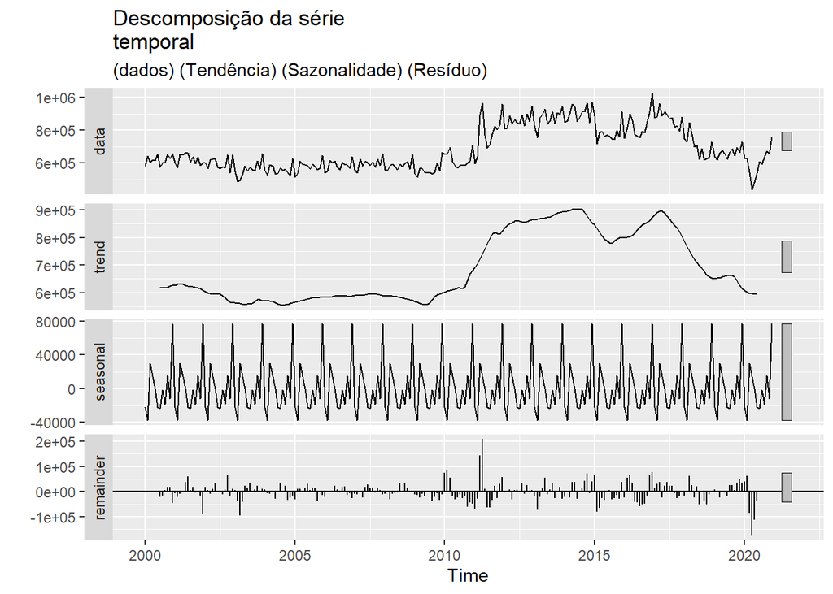

```r
sp_serie <- ts(sp_total[,3], start=2000, freq=12)

autoplot(decompose(sp_serie,"additive")) + labs(title = "Descomposição da série
temporal", subtitle = "(dados) (Tendência) (Sazonalidade) (Resíduo)")
```